# Aula 12 - Introdução à Econometria

Autor

João Ricardo F. de Lima

Data de Publicação

5 de agosto de 2024

# Modelos de Dados em Painel

## As Estruturas de Dados

**Corte transversal** (seção cruzada): amostra de indivíduos, consumidores, empresas, países, etc., tomada em um instante do tempo;

**Série Temporal**: observações sobre uma variável ou muitas variáveis ao longo do tempo;

**Cortes transversais independentes agrupados**: tem características tanto de corte transversal quanto de série temporal. Ocorre quando se agrupa cortes transversais coletados em diferentes instantes do tempo;

```r
#Cortes transversais agrupados: 2 anos de preços de imóveis.
library(wooldridge)

data(hprice3, package='wooldridge')

head(hprice3[c(175:184),c(1:9)],10)
```

|  | year | age | agesq | nbh | cbd | inst | linst | price | rooms |
| --- | --- | --- | --- | --- | --- | --- | --- | --- | --- |
| 175 | 1978 | 0 | 0 | 0 | 14000 | 14000 | 9.5468 | 121000 | 7 |
| 176 | 1978 | 0 | 0 | 0 | 14000 | 13000 | 9.4727 | 107000 | 7 |
| 177 | 1978 | 0 | 0 | 0 | 14000 | 13000 | 9.4727 | 119900 | 7 |
| 178 | 1978 | 0 | 0 | 0 | 14000 | 13000 | 9.4727 | 142500 | 7 |
| 179 | 1978 | 0 | 0 | 0 | 14000 | 13000 | 9.4727 | 84211 | 7 |
| 180 | 1981 | 81 | 6561 | 4 | 4000 | 1000 | 6.9078 | 49000 | 6 |
| 181 | 1981 | 71 | 5041 | 4 | 3000 | 2000 | 7.6009 | 52000 | 5 |
| 182 | 1981 | 31 | 961 | 4 | 3000 | 2000 | 7.6009 | 68000 | 6 |
| 183 | 1981 | 41 | 1681 | 4 | 3000 | 2000 | 7.6009 | 54000 | 6 |
| 184 | 1981 | 31 | 961 | 4 | 4000 | 2000 | 7.6009 | 70000 | 6 |

**Dados em Painel** (longitudinais): consiste em uma série temporal para cada registro do corte transversal do conjunto de dados. Em outras palavras, modelos de regressão com dados em painel são os que estudam o *mesmo grupo} de “entidades” ao longo do tempo.

```r
#Conjunto de Dados em Painel: Estatisticas Crime em estados dos USA

data(murder, package='wooldridge')

head(murder[,c(1:6)],9)
```

|  | id | state | year | mrdrte | exec | unem |
| --- | --- | --- | --- | --- | --- | --- |
| 1 | 1 | AL | 87 | 9.3 | 2 | 7.8 |
| 2 | 1 | AL | 90 | 11.6 | 5 | 6.8 |
| 3 | 1 | AL | 93 | 11.6 | 2 | 7.5 |
| 4 | 2 | AK | 87 | 10.1 | 0 | 10.8 |
| 5 | 2 | AK | 90 | 7.5 | 0 | 6.9 |
| 6 | 2 | AK | 93 | 9.0 | 0 | 7.6 |
| 7 | 3 | AZ | 87 | 7.5 | 0 | 6.2 |
| 8 | 3 | AZ | 90 | 7.7 | 0 | 5.3 |
| 9 | 3 | AZ | 93 | 8.6 | 3 | 6.2 |

## A Importância dos Dados em Painel

Baltagi (1995) lista os seguintes fatores como sendo vantagens dos dados em painel:

1. Trata com indivíduos, empresas, estados, países ao longo do tempo. É necessário que exista uma heterogeneidade nestas unidades, na qual pode ser frequentemente não observada;
2. Quando se combina cortes transversais e séries temporais, se tem dados com maior informação, maior variabilidade e menor colinearidade, mais graus de liberdade e eficiência.
3. Quando se estuda as observações do corte transversal ao longo do tempo, os dados em painel são mais adequados para se estudar as dinâmicas de mudanças;
4. Dados em painel podem detectar melhor e medir efeitos que não podem ser observados com dados empilhados de cross-section (cortes transversais agrupados) ou séries temporais.

## Notação Básica

Considere a indexação de todas as variáveis com $i$ para para o indivíduo $i = 1, ..., N$ e $t$ para o período $t = 1, ..., T$. Assim, o modelo de regressão linear clássico pode ser escrito como abaixo,

$$y_{it} = \beta_0 + x_{it}^{'} \beta + \varepsilon_{it}
\tag{1}$$

onde $x_{it}$ é um vetor de dimensão $K$ contendo as variáveis explicativas, sem considerar o termo constante. Esse tipo de modelo impõe que o intercepto $\beta_0$ e o coeficiente de inclinação em $\beta$ sejam idênticos para todos os indivíduos e períodos. O termo de erro em (1) varia ao longo dos indivíduos e tempo, capturando todos os fatores não observados que afetam $y_{it}$.

O modelo dado em (1) possui as premissas usuais requeridas para se ter estimadores não viesados, consistentes e eficientes.

$$E[\epsilon_{it}|x_{i1}, x_{i2}, \dots, x_{iT}]=0$$

$$Var[\epsilon_{it}|x_{i1}, x_{i2}, \dots, x_{iT}]=\sigma^2_\epsilon$$

$$Cov[\epsilon_{it},\epsilon_{js} |x_{i1}, x_{i2}, \dots, x_{iT}]=0 \quad \forall i \neq j \quad ou \quad t\neq s$$

## Cortes Transversais Agrupados

Uma razão para usar agrupamentos independentes de cortes transversais é aumentar o N. Com isso, pode-se obter estimadores mais precisos e estatísticas de teste mais poderosas;

Para refletir o fato de que a população pode ter distribuições diferentes em períodos de tempo distintos, é permitido ao intercepto diferir ao longo dos períodos;

Isso pode ser implementado através da adição de variáveis *dummies* para os $n-1$ períodos da amostra.

## Cortes Transversais Agrupados - Exemplo no R

O dataset cps contém dados de 1978 e 1985 da **Current Population Surveys**. O código abaixo importa os dados e estima o modelo sugerido em Wooldridge (2016).

```r
# Usando o R para verificar mudanças no retorno da eduação e a diferença salarial por gênero

data(cps78_85, package='wooldridge')

cps <- cps78_85

reg1 <- lm(lwage~y85*(educ+female)+exper
           +I((exper^2)/100)+union, data=cps)

summary(reg1)
```

```
Call:
lm(formula = lwage ~ y85 * (educ + female) + exper + I((exper^2)/100) +
    union, data = cps)

Residuals:
     Min       1Q   Median       3Q      Max
-2.56098 -0.25828  0.00864  0.26571  2.11669

Coefficients:
                  Estimate Std. Error t value Pr(>|t|)
(Intercept)       0.458933   0.093449   4.911 1.05e-06 ***
y85               0.117806   0.123782   0.952   0.3415
educ              0.074721   0.006676  11.192  < 2e-16 ***
female           -0.316709   0.036621  -8.648  < 2e-16 ***
exper             0.029584   0.003567   8.293 3.27e-16 ***
I((exper^2)/100) -0.039943   0.007754  -5.151 3.08e-07 ***
union             0.202132   0.030294   6.672 4.03e-11 ***
y85:educ          0.018461   0.009354   1.974   0.0487 *
y85:female        0.085052   0.051309   1.658   0.0977 .
---
Signif. codes:  0 '***' 0.001 '**' 0.01 '*' 0.05 '.' 0.1 ' ' 1

Residual standard error: 0.4127 on 1075 degrees of freedom
Multiple R-squared:  0.4262,    Adjusted R-squared:  0.4219
F-statistic:  99.8 on 8 and 1075 DF,  p-value: < 2.2e-16
```

O ano base é 1978. y85 é uma variável dummy igual a um se a observação se refere ao ano de 1985 e 0, caso contrário, ou seja, do ano de 1978. A constante é o intercepto do ano base. A constante mais o coeficiente de y85 é o intercepto de 1985.

O retorno da educação em 1978 é estimado (forma não precisa) em 7,5% e para o ano de 1985 é cerca de 1,846 mais elevado (7,5 + 1,846=9,346%).

Em 1978, tudo o mais constante, uma mulher ganhava precisamente `-27.145727`% a menos do que um homem. Em 1985 o valor é `-20.678185`%.

## O Estimador de Diferenças em Diferenças

O *estimador de diferença em diferenças* é um tipo de corte transversal agrupado que pode ser muito útil para avaliar o impacto de um determinado evento ou decisão política (em termos gerais);

Suponha que exista um evento exógeno que altere “x”. A ideia é comparar a mudança ao longo do tempo de um resultado de interesse entre um grupo de observações impactado e outro não impactado.

Um modelo simples de comparação dos resultados é a avaliação de um grupo antes e depois do evento, em uma regressão da forma

$$y_{it} = \alpha_0 + \beta D_t+ \varepsilon_{it}, \quad i=1, \dots, N, \quad t=0,1 \tag{2}$$
onde $D_t=1$ no período 1 (pós-evento) e $D_t=0$ no período 0, e $y_{it}$ mede o resultado;

Esta regressão com dados agrupados vai gerar uma estimativa do impacto da política igual a $\beta$

$$\hat{\beta} = N^{-1} \sum_{i}^{max}(y_{i1}-y_{i0})=\bar{y}_1-\bar{y}_0 \tag{3}$$

No entanto, esta especificação de um único grupo antes e após a intervenção tem o pressuposto forte de que o grupo permanece comparável no tempo;

Uma maneira de melhorar esta especificação consiste na inclusão de um grupo adicional que não sofreu tratamento, e para o qual se tenha observações nos dois períodos.

A especificação passa a ser então

$$y_{it}^j = \alpha + \alpha_1D_t+ \alpha^1D^J+\beta D_t^j+ \varepsilon_{it}^j
\tag{4}$$

onde j é para os grupos, t o tempo e $\varepsilon$ é o termo de erro homocedástico. A equação (4) pode ter a inclusão de covariadas.

Esta relação implica que para o grupo de tratamento, tem-se o pré-evento dado por

$$y_{i0}^1 = \alpha + \alpha^1D^1+ \varepsilon_{i0}^1
\tag{5}$$
e pós-evento

$$y_{i1}^1 = \alpha + \alpha_1+\alpha^1D^1+ \beta+\varepsilon_{i1}^1
\tag{6}$$
e o impacto é

$$y_{i1}^1 - y_{i0}^1= \alpha_1 + \beta+\varepsilon_{i1}^1 - \varepsilon_{i0}^1
\tag{7}$$

As equações correspondentes para o grupo não-tratado são

$$y_{i0}^0= \alpha + \varepsilon_{i0}^0
\tag{8}$$

$$y_{i1}^0= \alpha + \alpha_1+\varepsilon_{i1}^0
\tag{9}$$
e a diferença é

$$y_{i1}^0 - y_{i0}^0= \alpha_1 + \varepsilon_{i1}^0 - \varepsilon_{i0}^0
\tag{10}$$

O estimador de Diff-in-Diff vêm, então, da diferença entre as equações (7) e (10)

$$(y_{i1}^1 - y_{i0}^1)-(y_{i1}^0 - y_{i0}^0)= \beta+ (\varepsilon_{i1}^1 - \varepsilon_{i0}^1) - (\varepsilon_{i1}^0 - \varepsilon_{i0}^0)
\tag{11}$$

E assumindo que $E[(\varepsilon_{i1}^1 - \varepsilon_{i0}^1) - (\varepsilon_{i1}^0 - \varepsilon_{i0}^0)]=0$, obtém-se uma estimativa não viesada de $\beta$.

```r
# Usando o R para verificar efeito da localização de um incinerador sobre os preços de imóveis

data(kielmc, package='wooldridge')

kielmc <- kielmc

# Regressões separadas para 1978 e 1981

reg2 <- lm(rprice~nearinc, data=kielmc, subset=(year==1978))
summary(reg2)
```

```
Call:
lm(formula = rprice ~ nearinc, data = kielmc, subset = (year ==
    1978))

Residuals:
   Min     1Q Median     3Q    Max
-56517 -16605  -3193   8683 236307

Coefficients:
            Estimate Std. Error t value Pr(>|t|)
(Intercept)    82517       2654  31.094  < 2e-16 ***
nearinc       -18824       4745  -3.968 0.000105 ***
---
Signif. codes:  0 '***' 0.001 '**' 0.01 '*' 0.05 '.' 0.1 ' ' 1

Residual standard error: 29430 on 177 degrees of freedom
Multiple R-squared:  0.08167,   Adjusted R-squared:  0.07648
F-statistic: 15.74 on 1 and 177 DF,  p-value: 0.0001054
```

O intercepto mostra o valor médio dos imóveis e o coeficiente da variável dummy indica que mesmo antes da existência do incinerador, os imóveis daquela localidade era cerca de 18,8 mil dólares mais baixos do que o de outro distante do local.

```r
reg3 <- lm(rprice~nearinc, data=kielmc, subset=(year==1981))
summary(reg3)
```

```
Call:
lm(formula = rprice ~ nearinc, data = kielmc, subset = (year ==
    1981))

Residuals:
   Min     1Q Median     3Q    Max
-60678 -19832  -2997  21139 136754

Coefficients:
            Estimate Std. Error t value Pr(>|t|)
(Intercept)   101308       3093  32.754  < 2e-16 ***
nearinc       -30688       5828  -5.266 5.14e-07 ***
---
Signif. codes:  0 '***' 0.001 '**' 0.01 '*' 0.05 '.' 0.1 ' ' 1

Residual standard error: 31240 on 140 degrees of freedom
Multiple R-squared:  0.1653,    Adjusted R-squared:  0.1594
F-statistic: 27.73 on 1 and 140 DF,  p-value: 5.139e-07
```

No caso da regressão no ano de 1981 os resultados mostram que os preços dos imóveis subiram para 101 mil dólares aproximadamente e que os imóveis localizados perto de onde foi instalado o incinerador estão cerca de 30,7 mil dólares mais baratos.

Como se pode avaliar se a instalação do incinerador reduziu os preços dos imóveis? Para isto é preciso verificar como mudou o coeficiente da variável dummy nos dois períodos.

```r
#Diferença entre os coeficientes
coef.78<-coef(lm(rprice~nearinc, data=kielmc, subset=(year==1978)))
coef.81<-coef(lm(rprice~nearinc, data=kielmc, subset=(year==1981)))
coef.81[2]-coef.78[2]
```

```
 nearinc
-11863.9
```

```r
#Mesmos Resultados, outra forma
library(lmtest)
coeftest(lm(rprice~nearinc*y81, data=kielmc))
```

```
t test of coefficients:

            Estimate Std. Error t value  Pr(>|t|)
(Intercept)  82517.2     2726.9 30.2603 < 2.2e-16 ***
nearinc     -18824.4     4875.3 -3.8612 0.0001368 ***
y81          18790.3     4050.1  4.6395 5.117e-06 ***
nearinc:y81 -11863.9     7456.6 -1.5911 0.1125948
---
Signif. codes:  0 '***' 0.001 '**' 0.01 '*' 0.05 '.' 0.1 ' ' 1
```

Assim, por duas maneiras distintas de estimar o modelo, é possível verificar que a diferença entre os dois coefientes é de -11.863,9 dólares. Esta é a estimativa do efeito do incinerador sobre os preços dos imóveis pertos de sua localização. O valor da estimativa ficou conhecido na econometria como estimador de diferença em diferenças.

$$\hat{\delta}_1 = (\bar{rprice_{81,pr}} - \bar{rprice_{81,af}}) - (\bar{rprice_{78,pr}} - \bar{rprice_{78,af}})=-11.863,9$$

Contudo, precisa-se saber se este valor é ou não estatisticamente igual a zero. Como pode ser visto na segunda forma de estimar o valor, o valor de probabilidade é maior do que 0,10, não rejeitando a hipótese nula. Assim, não se pode afirmar que a instalação do incinerador alterou as diferenças de preços de imóveis mais distantes.

```r
coeftest(lm(log(rprice)~nearinc*y81, data=kielmc))
```

```
t test of coefficients:

             Estimate Std. Error  t value  Pr(>|t|)
(Intercept) 11.285424   0.030514 369.8386 < 2.2e-16 ***
nearinc     -0.339923   0.054555  -6.2308 1.476e-09 ***
y81          0.193094   0.045321   4.2606 2.691e-05 ***
nearinc:y81 -0.062649   0.083441  -0.7508    0.4533
---
Signif. codes:  0 '***' 0.001 '**' 0.01 '*' 0.05 '.' 0.1 ' ' 1
```

```r
#Inclusão de covariaveis
coeftest(lm(log(price)~nearinc*y81+lintst+lland+larea+rooms, data=kielmc) )
```

```
t test of coefficients:

             Estimate Std. Error t value  Pr(>|t|)
(Intercept)  5.458605   0.391396 13.9465 < 2.2e-16 ***
nearinc     -0.007325   0.055257 -0.1326 0.8946248
y81          0.434397   0.033164 13.0983 < 2.2e-16 ***
lintst       0.036397   0.034961  1.0411 0.2986509
lland        0.107617   0.028677  3.7527 0.0002084 ***
larea        0.500283   0.049820 10.0417 < 2.2e-16 ***
rooms        0.074249   0.018832  3.9427 9.945e-05 ***
nearinc:y81 -0.111671   0.059968 -1.8622 0.0635153 .
---
Signif. codes:  0 '***' 0.001 '**' 0.01 '*' 0.05 '.' 0.1 ' ' 1
```

As estimativas acima são para mostrar que logaritimizando a variável dependente se tem um efeito percentual do efeito do incinerador sobre os preços dos imóveis. O coeficiente mostra que os imóveis próximos do incinerador reduziram cerca de 6,3% no seu valor. Contudo, não é estatisticamente significativo.

Ao se inserir outras variáveis explicativas no modelo como a distância para a rodovia interestadual (instst), área do terreno (land), área construida (area) e o número de quartos (rooms), a redução passa a ser de aproximadamente 11,2% e estatisticamente significativo a 10% de probabilidade.

Diferentemente de um experimento estatístico verdadeiro, no qual os grupos de controle e de tratamento são obtidos de forma aleatória, no caso em análise os grupos surgem da mudança em um fator exógeno;

Assim, de forma a controlar diferenças sistemáticas entre os grupos, é preciso ter um amostra com dois anos de dados, uma anterior e outra posterior à mudança.

A amostra fica dividida em quatro grupos: o grupo de controle antes e depois da mudança e o grupo de tratamento antes e depois da mudança.

Como em Wooldridge(2016), considere que $A$ seja o grupo de controle e $B$ seja o grupo de tratamento. Assim, $dB$ é igual a 1 para as observações do grupo $B$ (tratamento) e zero, caso contrário. A variável **dummy** para o segundo período é dada por $d2$, de modo que a equação passa a ser

$$y = \beta_0 + \delta_0 d2 + \beta_1 dB + \delta_1 d2 dB + \text{outros fatores}
\tag{12}$$

onde $y$ é a variável de interesse, $\delta_1$ vai medir o efeito da decisão ou do evento exógeno;

Sem outros fatores, $\hat{\delta}_1$ será o estimador de diferenciamento:

$$\hat{\delta_1} = (\bar{y_{2,B}} - \bar{y_{2,A}}) - (\bar{y_{1,B}} - \bar{y_{1,A}})$$

### Suposição de tendências paralelas

A suposição de tendências paralelas (também conhecida como suposição de caminhos paralelos) é a suposição fundamental para a validade dos modelos Diff-in-Diff. Afirma que, na ausência do tratamento, a diferença nos resultados médios entre os grupos de tratamento e de controle teria permanecido constante ao longo do tempo. Isto implica que ambos os grupos teriam seguido a mesma tendência ao longo do tempo se o tratamento não tivesse sido implementado.

A suposição de tendências paralelas garante que quaisquer diferenças no resultado após o tratamento possam ser atribuídas ao próprio tratamento, e não a outros fatores. Se esta suposição for válida, o estimador Diff-in-Diff pode fornecer uma estimativa válida do efeito causal do tratamento.

Se a suposição de tendências paralelas for violada, as estimativas Diff-in-Diff podem ser tendenciosas. Nesses casos, deve-se considerar:

**Ajustando o Modelo:** Controle dos fatores que podem estar causando a divergência nas tendências.

**Métodos Alternativos:** Utilize outras técnicas econométricas, tais como Métodos de Controle Sintético.

### Exemplo no R

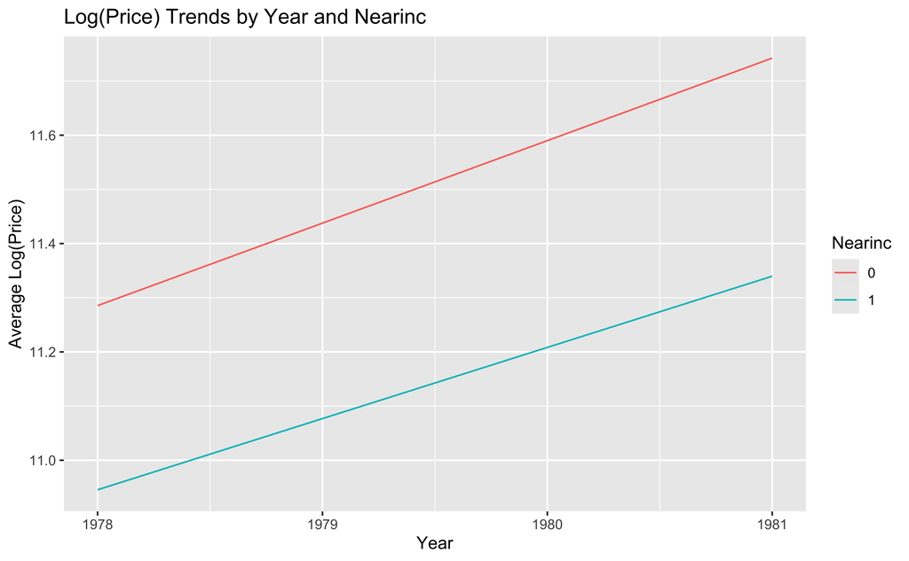

```r
# Load necessary libraries
library(ggplot2)
library(dplyr)

# Create a pre-treatment period indicator
kielmc$pre_period <- ifelse(kielmc$year < 1981, 1, 0)

# Create interaction terms for the pre-treatment period
kielmc$pre_nearinc <- kielmc$pre_period * kielmc$nearinc

# Visual Inspection
# Calculate average log(price) by year and nearinc
avg_log_price <- kielmc %>%
  group_by(year, nearinc) %>%
  summarize(avg_log_price = mean(log(price), na.rm = TRUE))

# Plot the trends
ggplot(avg_log_price, aes(x = year, y = avg_log_price, color = factor(nearinc))) +
  geom_line() +
  labs(title = "Log(Price) Trends by Year and Nearinc",
       x = "Year",
       y = "Average Log(Price)",
       color = "Nearinc")
```

```r
# Formal Statistical Test
# Run a regression with interaction terms for the pre-treatment period
model <- lm(log(price) ~ pre_period * nearinc + lintst + lland + larea + rooms, data = kielmc)
summary(model)
```

```
Call:
lm(formula = log(price) ~ pre_period * nearinc + lintst + lland +
    larea + rooms, data = kielmc)

Residuals:
     Min       1Q   Median       3Q      Max
-1.05763 -0.12172  0.01472  0.13736  0.82809

Coefficients:
                   Estimate Std. Error t value Pr(>|t|)
(Intercept)         5.89300    0.39285  15.001  < 2e-16 ***
pre_period         -0.43440    0.03316 -13.098  < 2e-16 ***
nearinc            -0.11900    0.05519  -2.156 0.031845 *
lintst              0.03640    0.03496   1.041 0.298651
lland               0.10762    0.02868   3.753 0.000208 ***
larea               0.50028    0.04982  10.042  < 2e-16 ***
rooms               0.07425    0.01883   3.943 9.94e-05 ***
pre_period:nearinc  0.11167    0.05997   1.862 0.063515 .
---
Signif. codes:  0 '***' 0.001 '**' 0.01 '*' 0.05 '.' 0.1 ' ' 1

Residual standard error: 0.2392 on 313 degrees of freedom
Multiple R-squared:  0.7086,    Adjusted R-squared:  0.7021
F-statistic: 108.7 on 7 and 313 DF,  p-value: < 2.2e-16
```

```r
# Test the interaction term for significance
coeftest(model)
```

```
t test of coefficients:

                    Estimate Std. Error  t value  Pr(>|t|)
(Intercept)         5.893002   0.392852  15.0006 < 2.2e-16 ***
pre_period         -0.434397   0.033164 -13.0983 < 2.2e-16 ***
nearinc            -0.118996   0.055193  -2.1560 0.0318450 *
lintst              0.036397   0.034961   1.0411 0.2986509
lland               0.107617   0.028677   3.7527 0.0002084 ***
larea               0.500283   0.049820  10.0417 < 2.2e-16 ***
rooms               0.074249   0.018832   3.9427 9.945e-05 ***
pre_period:nearinc  0.111671   0.059968   1.8622 0.0635153 .
---
Signif. codes:  0 '***' 0.001 '**' 0.01 '*' 0.05 '.' 0.1 ' ' 1
```

Conclusão: O valor p de 0,0635153 sugere que há alguma evidência contra a hipótese nula de não haver diferença nas tendências (ou seja, que as tendências pré-tratamento são diferentes entre os grupos de tratamento e de controle). No entanto, não é fortemente significativo. Embora o valor p esteja acima de 0,05, ainda está abaixo de 0,1, indicando que a evidência contra a suposição de tendências paralelas não é forte, mas vale a pena considerar.

## Controle Sintético

O Método de Controle Sintético (SCM) é uma técnica de inferência causal usada em estudos observacionais para avaliar o impacto de uma intervenção ou tratamento quando um ensaio tradicional de controle randomizado não é viável. É particularmente útil quando o tratamento é aplicado a uma **única unidade** (por exemplo, uma região, país ou organização) e existem múltiplas unidades de controle potenciais disponíveis.

**Conceitos chave**

1. Unidade Tratada: A unidade que recebe o tratamento ou intervenção.
2. Unidades de Controle: As unidades que não recebem o tratamento.
3. Controle Sintético: Uma combinação ponderada de unidades de controle construídas para se assemelhar às características da unidade tratada antes da intervenção.

### Etapas do Método de Controle Sintético

**Correspondência do período de pré-tratamento:** Selecione um conjunto de unidades de controle e use uma combinação ponderada dessas unidades para construir um controle sintético que corresponda melhor às características da unidade tratada durante o período de pré-tratamento.

**Comparação pós-tratamento:** Compare os resultados da unidade tratada e da unidade de controle sintética no período pós-tratamento para estimar o efeito do tratamento. Fundamentação teórica.

O SCM baseia-se na ideia de criar um cenário contrafactual para a unidade tratada, utilizando uma combinação de unidades de controle. As principais etapas envolvem:

1. Escolhendo Variáveis Preditoras: Selecione variáveis preditoras que influenciam a variável de resultado. Esses preditores são usados para combinar a unidade tratada com as unidades de controle.
2. Otimização: Determine os pesos das unidades de controle que minimizem a diferença entre a unidade tratada e o controle sintético em termos de variáveis preditoras durante o período pré-tratamento.
3. Estimativa do efeito do tratamento: No período pós-tratamento, a diferença entre o resultado real da unidade tratada e o resultado do controle sintético é atribuída ao efeito do tratamento.

### Vantagens do SCM

1. Flexibilidade: o SCM não requer um grande número de unidades tratadas e pode atender casos com uma única unidade tratada.
2. Nenhuma suposição de tendências paralelas: Ao contrário da diferença em diferenças (Diff-in-Diff), o SCM não depende muito da suposição de tendências paralelas, tornando-o mais robusto em determinados contextos.
3. Transparente e Intuitivo: O método fornece uma forma clara e interpretável de construir um cenário contrafactual e estimar o efeito do tratamento.

### Considerações práticas

**Seleção de Preditores:** A escolha das variáveis preditoras é crucial. Eles devem ser relevantes e prever com precisão a variável resultado.

**Otimização de peso:** O processo de otimização para determinar os pesos deve garantir que o controle sintético corresponda de perto à unidade tratada no período de pré-tratamento.

**Testes de Placebo:** Realize testes de placebo aplicando o SCM a outras unidades de controle para verificar a robustez do efeito estimado do tratamento.

O Método de Controle Sintético é uma ferramenta poderosa para inferência causal, especialmente quando se trata de uma única unidade tratada e de múltiplas unidades de controle. Ao selecionar cuidadosamente os preditores e otimizar os pesos, os pesquisadores podem construir um cenário contrafactual confiável e estimar o efeito do tratamento com maior precisão e robustez.

### Método de Controle Sintético: Formulação Matemática

### Notação

- **Unidades Tratadas**: Denotada como $( J+1 )$.
- **Unidades de Controle**: Denotada como $( 1, 2, \ldots, J )$.
- **Pre-tratamento Periodo**: $( t = 1, 2, \ldots, T_0 )$.
- **Pós-tratamento Periodo**: $( t = T_0 + 1, T_0 + 2, \ldots, T )$.
- **Variável de Resultado**: $( Y_{it} )$ para a unidade $( i)$ no tempo $( t)$.

### Objetivo

Construa um controle sintético que se aproxime do resultado da unidade tratada $( Y_{J+1, t})$ no período pré-tratamento. Em seguida, utilize este controle sintético para estimar o resultado contrafactual no período pós-tratamento.

## Passos

### 1. Escolha preditores e resultados

- **Preditores**: $( X_{i} = (X_{i1}, X_{i2}, \ldots, X_{iK})')$, onde $( X_{ik} )$ são características pré-tratamento da unidade $( i )$ (por exemplo, variáveis demográficas e econômicas).
- **Resultados**: $( Y_{it} )$ para $( t = 1, 2, \ldots, T_0 )$.

### 2. Construa o controle sintético

Encontre pesos $( W = (w_1, w_2, \ldots, w_J) )$ tais que a média ponderada das unidades de controle se aproxime da unidade tratada no período de pré-tratamento.

$$\sum_{j=1}^J w_j X_j \approx X_{J+1}$$

Os pesos $( W )$ não são negativos e somam um:

$$w_j \geq 0 \quad \text{and} \quad \sum_{j=1}^J w_j = 1$$

### 3. Minimize a distância

Os pesos $( W )$ são escolhidos para minimizar a distância entre os preditores da unidade tratada e o controle sintético:

$$\min_W \left\| X_{J+1} - \sum_{j=1}^J w_j X_j \right\|_V$$

onde $( V )$ é uma matriz diagonal que atribui pesos às variáveis preditoras.

### 4. Estime o resultado do controle sintético

Use os pesos otimizados para estimar o resultado do controle sintético para a unidade tratada no período pós-tratamento:

$$\hat{Y}_{J+1, t}^\text{synthetic} = \sum_{j=1}^J w_j Y_{j, t} \quad \text{for} \quad t = T_0 + 1, T_0 + 2, \ldots, T$$

### 5. Estime o efeito do tratamento

O efeito do tratamento é a diferença entre o resultado real e o resultado do controle sintético para a unidade tratada no período pós-tratamento:

$$\tau_{J+1, t} = Y_{J+1, t} - \hat{Y}_{J+1, t}^\text{synthetic} \quad \text{for} \quad t = T_0 + 1, T_0 + 2, \ldots, T$$

### Exemplo no R

Neste exemplo, se quer estudar o impacto de um evento significativo na esperança de vida de um país. Especificamente, o exame do impacto do genocídio de 1994 em Ruanda, na esperança de vida de sua população. Ao utilizar o método de controle sintético, pretende-se construir uma “versão sintética” de Ruanda, que represente o que teria acontecido à esperança de vida do país se o genocídio não tivesse ocorrido. Isto permite estimar o efeito causal do genocídio na esperança de vida.

```r
library(gapminder)
library(dplyr)
library(Synth)

# Carrega o dataset
data("gapminder", package = "gapminder")

# Inspeciona o dataset
head(gapminder)
```

| country | continent | year | lifeExp | pop | gdpPercap |
| --- | --- | --- | --- | --- | --- |
| Afghanistan | Asia | 1952 | 28.801 | 8425333 | 779.4453 |
| Afghanistan | Asia | 1957 | 30.332 | 9240934 | 820.8530 |
| Afghanistan | Asia | 1962 | 31.997 | 10267083 | 853.1007 |
| Afghanistan | Asia | 1967 | 34.020 | 11537966 | 836.1971 |
| Afghanistan | Asia | 1972 | 36.088 | 13079460 | 739.9811 |
| Afghanistan | Asia | 1977 | 38.438 | 14880372 | 786.1134 |

```r
summary(gapminder)
```

```
        country        continent        year         lifeExp
 Afghanistan:  12   Africa  :624   Min.   :1952   Min.   :23.60
 Albania    :  12   Americas:300   1st Qu.:1966   1st Qu.:48.20
 Algeria    :  12   Asia    :396   Median :1980   Median :60.71
 Angola     :  12   Europe  :360   Mean   :1980   Mean   :59.47
 Argentina  :  12   Oceania : 24   3rd Qu.:1993   3rd Qu.:70.85
 Australia  :  12                  Max.   :2007   Max.   :82.60
 (Other)    :1632
      pop              gdpPercap
 Min.   :6.001e+04   Min.   :   241.2
 1st Qu.:2.794e+06   1st Qu.:  1202.1
 Median :7.024e+06   Median :  3531.8
 Mean   :2.960e+07   Mean   :  7215.3
 3rd Qu.:1.959e+07   3rd Qu.:  9325.5
 Max.   :1.319e+09   Max.   :113523.1
```

```r
# Check the available years
unique(gapminder$year)
```

```
 [1] 1952 1957 1962 1967 1972 1977 1982 1987 1992 1997 2002 2007
```

```r
# Choose a country for treatment (e.g., Rwanda due to the 1994 genocide affecting life expectancy)
treated_country <- "Rwanda"
treatment_year <- 1994

# Create a numeric identifier for each country
gapminder <- gapminder %>%
  mutate(country_id = as.numeric(as.factor(country)),
         treatment = ifelse(country == treated_country & year >= treatment_year, 1, 0))

# Verify the country_id
head(gapminder)
```

| country | continent | year | lifeExp | pop | gdpPercap | country_id | treatment |
| --- | --- | --- | --- | --- | --- | --- | --- |
| Afghanistan | Asia | 1952 | 28.801 | 8425333 | 779.4453 | 1 | 0 |
| Afghanistan | Asia | 1957 | 30.332 | 9240934 | 820.8530 | 1 | 0 |
| Afghanistan | Asia | 1962 | 31.997 | 10267083 | 853.1007 | 1 | 0 |
| Afghanistan | Asia | 1967 | 34.020 | 11537966 | 836.1971 | 1 | 0 |
| Afghanistan | Asia | 1972 | 36.088 | 13079460 | 739.9811 | 1 | 0 |
| Afghanistan | Asia | 1977 | 38.438 | 14880372 | 786.1134 | 1 | 0 |

```r
# Get the numeric identifier for the treated country
treated_country_id <- gapminder %>%
  filter(country == treated_country) %>%
  pull(country_id) %>%
  unique()

# Ensure the identifier is numeric
gapminder <- gapminder %>%
  mutate(country_id = as.numeric(country_id))

# Prepare data for Synth package with correct years
dataprep.out <- dataprep(
  foo = as.data.frame(gapminder),
  predictors = c("gdpPercap", "pop"),
  predictors.op = "mean",
  time.predictors.prior = c(1952, 1957, 1962, 1967, 1972, 1977, 1982, 1987, 1992),
  dependent = "lifeExp",
  unit.variable = "country_id",
  time.variable = "year",
  treatment.identifier = treated_country_id,
  controls.identifier = setdiff(unique(gapminder$country_id), treated_country_id),
  time.optimize.ssr = c(1952, 1957, 1962, 1967, 1972, 1977, 1982, 1987, 1992),
  time.plot = c(1952, 1957, 1962, 1967, 1972, 1977, 1982, 1987, 1992, 1997, 2002, 2007)
)

# Fit the synthetic control model
synth.out <- synth(dataprep.out)
```

[output not shown]

```r
# Extract the results
synth.tables <- synth.tab(dataprep.res = dataprep.out, synth.res = synth.out)

# Print the results
print(synth.tables$tab.w)
```

```
    w.weights unit.names unit.numbers
1       0.001          1            1
2       0.000          2            2
3       0.000          3            3
4       0.000          4            4
5       0.000          5            5
6       0.000          6            6
7       0.000          7            7
8       0.000          8            8
9       0.000          9            9
10      0.000         10           10
11      0.000         11           11
12      0.000         12           12
13      0.000         13           13
14      0.000         14           14
```

[output cut: 127 more lines]

```r
print(synth.tables$tab.pred)
```

```
              Treated   Synthetic Sample Mean
gdpPercap     652.149     655.983     6250.07
pop       4406184.000 4410316.568 25805843.12
```

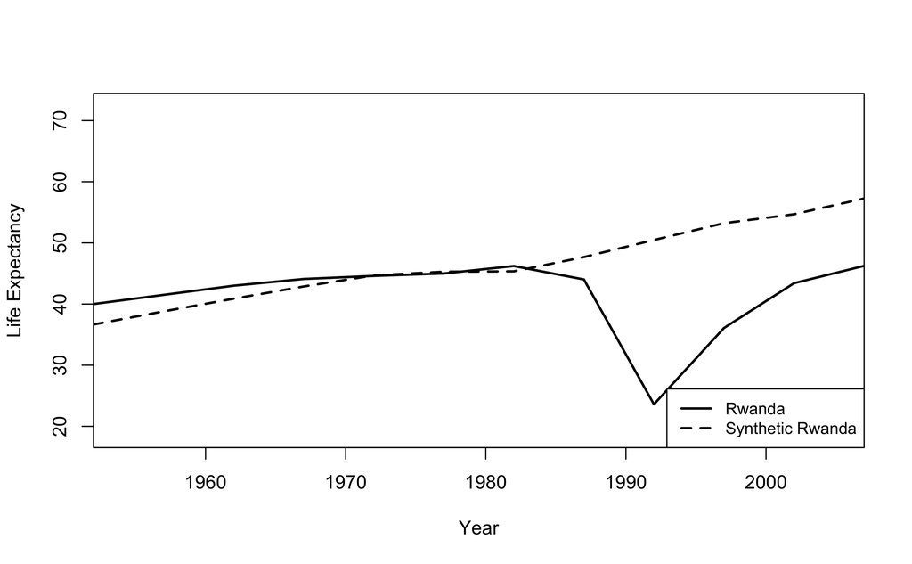

```r
# Plot the synthetic control results
path.plot(synth.res = synth.out, dataprep.res = dataprep.out,
          Ylab = "Life Expectancy", Xlab = "Year",
          Legend = c("Rwanda", "Synthetic Rwanda"),
          Legend.position = "bottomright")
```

# Exemplo no Python

```python
import pandas as pd
import wooldridge
from linearmodels.panel import PanelOLS, RandomEffects
import statsmodels.api as sm
import statsmodels.formula.api as smf

#Cortes transversais agrupados: 2 anos de preços de imóveis.
#Carregar dados no computador
hprice3 = wooldridge.data('hprice3')
#Observar a estrutura dos dados
wooldridge.data('hprice3', description=True)
```

```
name of dataset: hprice3
no of variables: 19
no of observations: 321

+----------+---------------------------------+
| variable | label                           |
+----------+---------------------------------+
| year     | 1978, 1981                      |
| age      | age of house                    |
| agesq    | age^2                           |
| nbh      | neighborhood, 1-6               |
| cbd      | dist. to cent. bus. dstrct, ft. |
| inst     | dist. to interstate, ft.        |
| linst    | log(inst)                       |
| price    | selling price                   |
| rooms    | # rooms in house                |
| area     | square footage of house         |
| land     | square footage lot              |
| baths    | # bathrooms                     |
| dist     | dist. from house to incin., ft. |
| ldist    | log(dist)                       |
| lprice   | log(price)                      |
| y81      | =1 if year = 1981               |
| larea    | log(area)                       |
| lland    | log(land)                       |
| linstsq  | linst^2                         |
+----------+---------------------------------+

-
```

```python
# Selecione as linhas e colunas necessárias
selected_data = hprice3.iloc[174:184, 0:9]  #Lembre-se de que Python usa indexação baseada em zero e não mostra o ultimo valor selecionado.

# Mostra as 10 primeiras linhas
print(selected_data.head(10))
```

```
     year  age   agesq  nbh      cbd     inst   linst     price  rooms
174  1978    0     0.0    0  14000.0  14000.0  9.5468  121000.0      7
175  1978    0     0.0    0  14000.0  13000.0  9.4727  107000.0      7
176  1978    0     0.0    0  14000.0  13000.0  9.4727  119900.0      7
177  1978    0     0.0    0  14000.0  13000.0  9.4727  142500.0      7
178  1978    0     0.0    0  14000.0  13000.0  9.4727   84211.0      7
179  1981   81  6561.0    4   4000.0   1000.0  6.9078   49000.0      6
180  1981   71  5041.0    4   3000.0   2000.0  7.6009   52000.0      5
181  1981   31   961.0    4   3000.0   2000.0  7.6009   68000.0      6
182  1981   41  1681.0    4   3000.0   2000.0  7.6009   54000.0      6
183  1981   31   961.0    4   4000.0   2000.0  7.6009   70000.0      6
```

```python
#Conjunto de Dados em Painel: Estatisticas Crime em estados dos USA
murder = wooldridge.data('murder')
#Observar a estrutura dos dados
wooldridge.data('murder', description=True)
```

```
name of dataset: murder
no of variables: 13
no of observations: 153

+----------+--------------------------------+
| variable | label                          |
+----------+--------------------------------+
| id       | state identifier               |
| state    | postal code                    |
| year     | 87, 90, or 93                  |
| mrdrte   | murders per 100,000 people     |
| exec     | total executions, past 3 years |
| unem     | annual unem. rate              |
| d90      | =1 if year == 90               |
| d93      | =1 if year == 93               |
| cmrdrte  | mrdrte - mrdrte[_n-1]          |
| cexec    | exec - exec[_n-1]              |
| cunem    | unem - unem[_n-1]              |
| cexec_1  | cexec[_n-1]                    |
| cunem_1  | cunem[_n-1]                    |
+----------+--------------------------------+

From the Statistical Abstract of the United States, 1995 (Tables 310
and 357), 1992 (Table 289). The execution data originally come from
the U.S. Bureau of Justice Statistics, Capital Punishment Annual.
```

```python
# Selecione as linhas e colunas necessárias
selected_data = murder.iloc[:, 0:6]  #Lembre-se de que Python usa indexação baseada em zero e não mostra o ultimo valor selecionado.

# Mostra as 9 primeiras linhas
print(selected_data.head(9))
```

```
   id state  year  mrdrte  exec  unem
0   1    AL    87     9.3     2   7.8
1   1    AL    90    11.6     5   6.8
2   1    AL    93    11.6     2   7.5
3   2    AK    87    10.1     0  10.8
4   2    AK    90     7.5     0   6.9
5   2    AK    93     9.0     0   7.6
6   3    AZ    87     7.5     0   6.2
7   3    AZ    90     7.7     0   5.3
8   3    AZ    93     8.6     3   6.2
```

```python
# Usando o Python para verificar mudanças no retorno da eduação e a diferença salarial por gênero

cps = wooldridge.data('cps78_85')

# Define a as variáveis do modelo
formula = 'lwage ~ y85 * (educ + female) + exper + I((exper**2) / 100) + union'

# Fit the linear regression model
reg1 = smf.ols(formula, data=cps).fit()

# Display the summary of the regression
print(reg1.summary())
```

```
                            OLS Regression Results
==============================================================================
Dep. Variable:                  lwage   R-squared:                       0.426
Model:                            OLS   Adj. R-squared:                  0.422
Method:                 Least Squares   F-statistic:                     99.80
Date:                Seg, 05 Ago 2024   Prob (F-statistic):          4.46e-124
Time:                        08:53:30   Log-Likelihood:                -574.24
No. Observations:                1084   AIC:                             1166.
Df Residuals:                    1075   BIC:                             1211.
Df Model:                           8
Covariance Type:            nonrobust
=========================================================================================
                            coef    std err          t      P>|t|      [0.025      0.975]
-----------------------------------------------------------------------------------------
Intercept                 0.4589      0.093      4.911      0.000       0.276       0.642
y85                       0.1178      0.124      0.952      0.341      -0.125       0.361
educ                      0.0747      0.007     11.192      0.000       0.062       0.088
female                   -0.3167      0.037     -8.648      0.000      -0.389      -0.245
y85:educ                  0.0185      0.009      1.974      0.049       0.000       0.037
y85:female                0.0851      0.051      1.658      0.098      -0.016       0.186
exper                     0.0296      0.004      8.293      0.000       0.023       0.037
I((exper ** 2) / 100)    -0.0399      0.008     -5.151      0.000      -0.055      -0.025
union                     0.2021      0.030      6.672      0.000       0.143       0.262
==============================================================================
Omnibus:                       83.747   Durbin-Watson:                   1.918
Prob(Omnibus):                  0.000   Jarque-Bera (JB):              317.985
Skew:                          -0.271   Prob(JB):                     8.92e-70
Kurtosis:                       5.597   Cond. No.                         296.
==============================================================================

Notes:
[1] Standard Errors assume that the covariance matrix of the errors is correctly specified.
```

## O Estimador de Diferenças em Diferenças no Python

```python
# Usando o Python para verificar efeito da localização de um incinerador sobre os preços de imóveis

kielmc = wooldridge.data('kielmc')

# Regressões separadas para 1978 e 1981

reg2 = smf.ols('rprice ~ nearinc', data=kielmc, subset=kielmc['year'] == 1978).fit()

print(reg2.summary())
```

```
                            OLS Regression Results
==============================================================================
Dep. Variable:                 rprice   R-squared:                       0.082
Model:                            OLS   Adj. R-squared:                  0.076
Method:                 Least Squares   F-statistic:                     15.74
Date:                Seg, 05 Ago 2024   Prob (F-statistic):           0.000105
Time:                        08:53:31   Log-Likelihood:                -2094.9
No. Observations:                 179   AIC:                             4194.
Df Residuals:                     177   BIC:                             4200.
Df Model:                           1
Covariance Type:            nonrobust
==============================================================================
                 coef    std err          t      P>|t|      [0.025      0.975]
------------------------------------------------------------------------------
Intercept   8.252e+04   2653.790     31.094      0.000    7.73e+04    8.78e+04
nearinc    -1.882e+04   4744.594     -3.968      0.000   -2.82e+04   -9461.117
==============================================================================
Omnibus:                      173.455   Durbin-Watson:                   1.707
Prob(Omnibus):                  0.000   Jarque-Bera (JB):             4526.710
Skew:                           3.520   Prob(JB):                         0.00
Kurtosis:                      26.609   Cond. No.                         2.42
==============================================================================

Notes:
[1] Standard Errors assume that the covariance matrix of the errors is correctly specified.
```

```python
reg3 = smf.ols('rprice ~ nearinc', data=kielmc, subset=kielmc['year'] == 1981).fit()

print(reg3.summary())
```

```
                            OLS Regression Results
==============================================================================
Dep. Variable:                 rprice   R-squared:                       0.165
Model:                            OLS   Adj. R-squared:                  0.159
Method:                 Least Squares   F-statistic:                     27.73
Date:                Seg, 05 Ago 2024   Prob (F-statistic):           5.14e-07
Time:                        08:53:31   Log-Likelihood:                -1670.1
No. Observations:                 142   AIC:                             3344.
Df Residuals:                     140   BIC:                             3350.
Df Model:                           1
Covariance Type:            nonrobust
==============================================================================
                 coef    std err          t      P>|t|      [0.025      0.975]
------------------------------------------------------------------------------
Intercept   1.013e+05   3093.027     32.754      0.000    9.52e+04    1.07e+05
nearinc    -3.069e+04   5827.709     -5.266      0.000   -4.22e+04   -1.92e+04
==============================================================================
Omnibus:                       23.943   Durbin-Watson:                   1.380
Prob(Omnibus):                  0.000   Jarque-Bera (JB):               38.601
Skew:                           0.832   Prob(JB):                     4.15e-09
Kurtosis:                       4.939   Cond. No.                         2.44
==============================================================================

Notes:
[1] Standard Errors assume that the covariance matrix of the errors is correctly specified.
```

```python
# Extrai os coeficientes
coef_78 = reg2.params
coef_81 = reg3.params

# Diferença entre os coeficientes de 'nearinc'
diff = coef_81['nearinc'] - coef_78['nearinc']

# Mostra a diferença
print(f"Diferença entre coeficientes 'nearinc' : {diff:.0f}")
```

```
Diferença entre coeficientes 'nearinc' : -11864
```

```python
#Mesmos Resultados, outra forma
reg4 = smf.ols('rprice ~ nearinc * y81', data=kielmc).fit()

print(reg4.summary())
```

```
                            OLS Regression Results
==============================================================================
Dep. Variable:                 rprice   R-squared:                       0.174
Model:                            OLS   Adj. R-squared:                  0.166
Method:                 Least Squares   F-statistic:                     22.25
Date:                Seg, 05 Ago 2024   Prob (F-statistic):           4.22e-13
Time:                        08:53:31   Log-Likelihood:                -3765.2
No. Observations:                 321   AIC:                             7538.
Df Residuals:                     317   BIC:                             7554.
Df Model:                           3
Covariance Type:            nonrobust
===============================================================================
                  coef    std err          t      P>|t|      [0.025      0.975]
-------------------------------------------------------------------------------
Intercept    8.252e+04   2726.910     30.260      0.000    7.72e+04    8.79e+04
nearinc     -1.882e+04   4875.322     -3.861      0.000   -2.84e+04   -9232.293
y81          1.879e+04   4050.065      4.640      0.000    1.08e+04    2.68e+04
nearinc:y81 -1.186e+04   7456.646     -1.591      0.113   -2.65e+04    2806.867
==============================================================================
Omnibus:                      192.562   Durbin-Watson:                   1.557
Prob(Omnibus):                  0.000   Jarque-Bera (JB):             2462.071
Skew:                           2.217   Prob(JB):                         0.00
Kurtosis:                      15.822   Cond. No.                         6.05
==============================================================================

Notes:
[1] Standard Errors assume that the covariance matrix of the errors is correctly specified.
```

[output not shown]